# Linearization and 'Instantaneous' Slope -- Examples from Class Oct. 12

If a nonlinear function is "smooth" enough at a point $(a,f(a))$, then when you zoom in close enough around the point $(a,f(a))$ the function, $f$, will look a line. The function will look linear. The linear function (or line) that approximates $f$ near $(a,f(a))$ is called the linearization of the function $f$ at $x=a$. We can write the linearization of $y - y_0 = m(x - x_0)$ or $L(x) = m(x - x_0) + y_0$ where $x_0=a$ and $f(x_0) = f(a)$. The point $(a,f(a)) = (x_0,y_0)$ and the slope, $m$, is the derivative of the funciton $f$ at $x=a$.

## Example 1

We will consider the function, $f_1(x) = x^4 - 10x^2 + 3x$ at $x=3$. After defining the function, we compute $f_1(3) = 0$. So when the input of $f$ is 3 the corresponding output will be 0.

```r
f1 <- function(x){x^4 -10*x^2 +3*x}

f1(3)
```

```
## [1] 0
```

The following four graphs (top left, top right, bottom left, bottom right) show that when we zoom in on the function $f_1$ at the point $(3,0) = (a, f_1(a))$ the polynomial does look like a line. The point $(3,0)$ is highlighted in red in each plot. Locally, near the point $(3,0)$, the line $y-0 = m(x-3)$ is a linear approximation for the function $f_1$. The slope, $m$, is the derivative of $f_1$ at $x=3$.

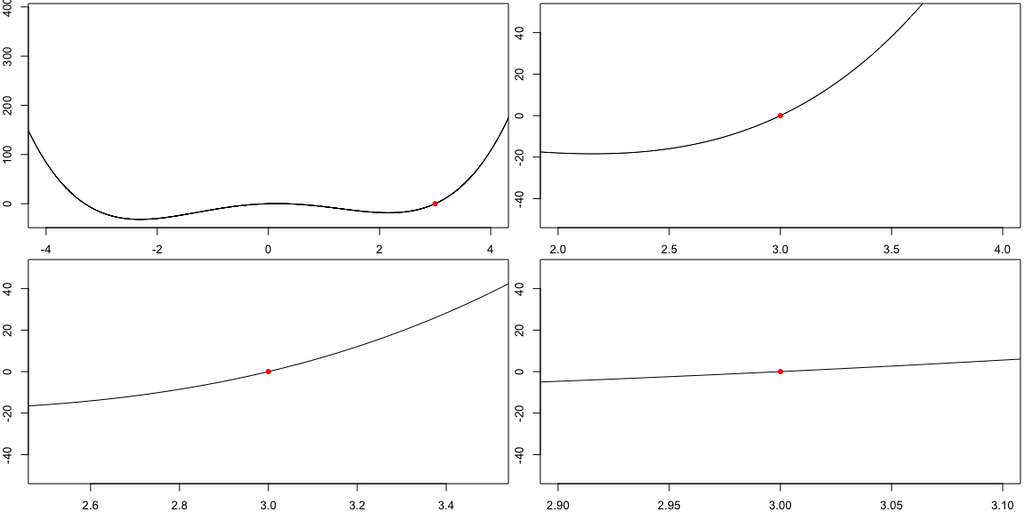

```r
x <- seq(-5,5,1e-3)
y1 <- f1(x)

par(mfrow=c(2,2),mar=c(2,2,0.25,0.25))
plot(x,y1,type='l',xlim=c(-4,4))
points(3,f1(3),pch=16,col=2)
plot(x,y1,type='l',xlim=c(2,4),ylim=c(-50,50))
points(3,f1(3),pch=16,col=2)
plot(x,y1,type='l',xlim=c(2.5,3.5),ylim=c(-50,50))
points(3,f1(3),pch=16,col=2)
plot(x,y1,type='l',xlim=c(2.9,3.1),ylim=c(-50,50))
points(3,f1(3),pch=16,col=2)
```

What is the value of $m$? We complete the following table to approximate the value of $m$. We can compute the all the values for function at the same time using a vector of input values (x-values). We can compute all the slopes at the same time using a vector of input (x-values) values and a vector of output values (y-values).

```r
x0 <- 3
y0 <- f1(3)

#Define a vector of input values (x-values).
x.vals <- c(2,2.5,2.9,2.99,2.999,3,3.001,3.01,3.1,3.5,4)
#Compute the output values (y-values), "column 2".
y.vals <- f1(x.vals)
#Compute the slopes, "column 3".
slopes <- (y.vals-y0)/(x.vals-x0)

table <- as.data.frame(cbind(x.vals,y.vals,slopes))
names(table) <- c('x','y=f1(x)','slope between (3,0) and (x,y)')

print(table)
```

```
##        x      y=f1(x) slope between (3,0) and (x,y)
## 1  2.000 -18.00000000                      18.00000
## 2  2.500 -15.93750000                      31.87500
## 3  2.900  -4.67190000                      46.71900
## 4  2.990  -0.50561199                      50.56120
## 5  2.999  -0.05095601                      50.95601
## 6  3.000   0.00000000                           NaN
## 7  3.001   0.05104401                      51.04401
## 8  3.010   0.51441201                      51.44120
## 9  3.100   5.55210000                      55.52100
## 10 3.500  38.06250000                      76.12500
## 11 4.000 108.00000000                     108.00000
```

Looking at the at the values of the slopes in column 3, as $x$ moves from 2 towards 3 the slope increases from 18 toward 51 and as $x$ moves from 4 towards 3 the slope decreases from 108 toward 51. So we could guess that $m = 51$ for this example.

We now look three additional examples of nonlinear functions. Notice that each function looks linear when we zoom in close enough.

## Example 2

We will consider the function, $f_2(x) = e^{2x} - 1$ at $x=0$. After defining the function, we compute $f_2(0) = 0$. So when the input of $f$ is 0 the corresponding output will be 0.

```r
f2 <- function(x){exp(2*x)-1}

f2(0)
```

```
## [1] 0
```

[figure not shown]

```r
x <- seq(-5,5,1e-3)
y2 <- f2(x)

par(mfrow=c(2,2),mar=c(2,2,0.25,0.25))
plot(x,y1,type='l',xlim=c(-4,4))
points(3,f1(3),pch=16,col=2)
plot(x,y1,type='l',xlim=c(2,4),ylim=c(-50,50))
points(3,f1(3),pch=16,col=2)
plot(x,y1,type='l',xlim=c(2.5,3.5),ylim=c(-50,50))
points(3,f1(3),pch=16,col=2)
plot(x,y1,type='l',xlim=c(2.9,3.1),ylim=c(-50,50))
points(3,f1(3),pch=16,col=2)
```

What is $m$ in this example? We will continue this discussion tomorrow in class.

## Example 3

We will consider the function, $f_3(x) = \sqrt[3]{x-1}$ at $x=2$. After defining the function, we compute $f_3(2) = 1$. So when the input of $f$ is 2 the corresponding output will be 1.

```r
f3 <- function(x){sign(x-1)*(abs(x-1))^(1/3)}

f3(2)
```

```
## [1] 1
```

The following four graphs (top left, top right, bottom left, bottom right) show that when we zoom in on the function $f_3$ at the point $(2,1) = (a, f_3(a))$ the cube root function does look like a line. The point $(2,1)$ is highlighted in red in each plot. Locally, near the point $(2,1)$, the line $y-1 = m(x-2)$ is a linear approximation for the function $f_3$. The slope, $m$, is the derivative of $f_3$ at $x=2$.

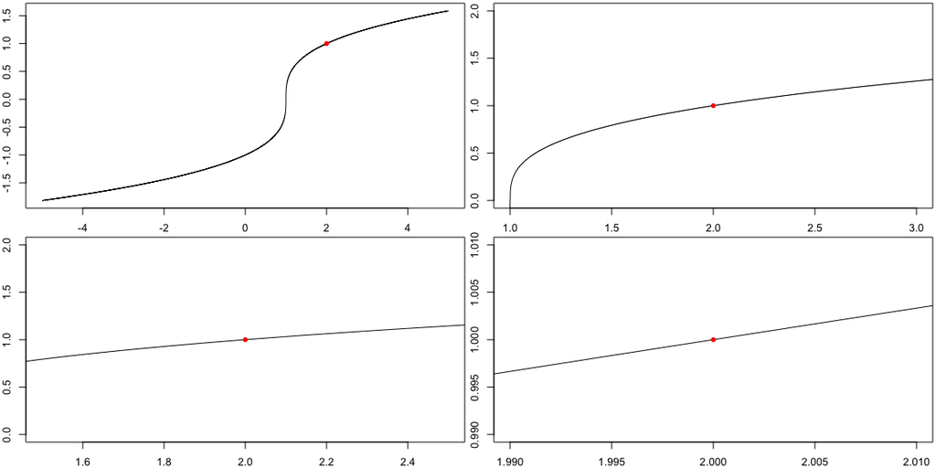

```r
x3 <- seq(-5,5,1e-3)
y3 <- f3(x3)
par(mfrow=c(2,2),mar=c(2,2,0.25,0.25))
plot(x3,y3,type='l',xlim=c(-5,5))
points(2,f3(2),pch=16,col=2)
plot(x3,y3,type='l',xlim=c(1,3),ylim=c(0,2))
points(2,f3(2),pch=16,col=2)
plot(x3,y3,type='l',xlim=c(1.5,2.5),ylim=c(0,2))
points(2,f3(2),pch=16,col=2)
plot(x3,y3,type='l',xlim=c(1.99,2.01),ylim=c(0.99,1.01))
points(2,f3(2),pch=16,col=2)
```

What is $m$ in this example? We will continue this discussion tomorrow in class.

## Example 4

We will consider the function, $f_4(x) = 3\ln(x-2)$ at $x=2.75$. After defining the function, we compute $f_4(2.75) = 3\ln(0.75)$. So when the input of $f$ is 2.75 the corresponding output will be $3\ln(0.75) \approx -0.863$.

```r
f4 <- function(x){3*log(x-2)}

f4(2.75)
```

```
## [1] -0.8630462
```

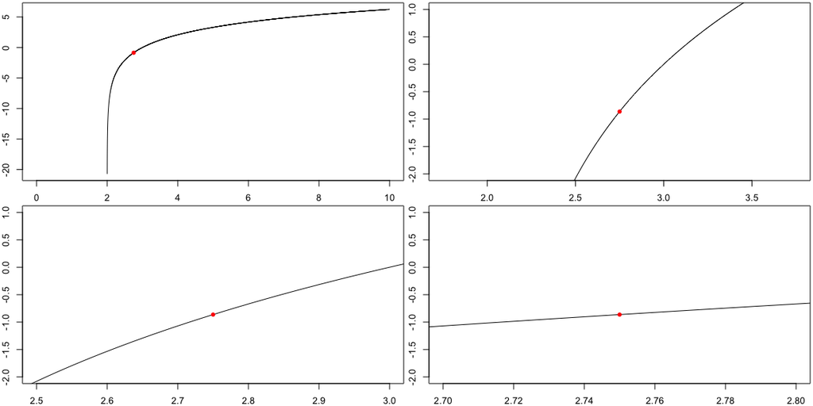

```r
x4 <- seq(2,10,1e-3)
y4 <- f4(x4)
par(mfrow=c(2,2),mar=c(2,2,0.25,0.25))
plot(x4,y4,type='l',xlim=c(0,10))
points(2.75,f4(2.75),pch=16,col=2)
plot(x4,y4,type='l',xlim=c(1.75,3.75),ylim=c(-2,1))
points(2.75,f4(2.75),pch=16,col=2)
plot(x4,y4,type='l',xlim=c(2.5,3),ylim=c(-2,1))
points(2.75,f4(2.75),pch=16,col=2)
plot(x4,y4,type='l',xlim=c(2.7,2.8),ylim=c(-2,1))
points(2.75,f4(2.75),pch=16,col=2)
```

What is $m$ in this example? We will continue this discussion tomorrow in class.

Key ideas from these examples include that all nonlinear functions have local linearizations when they are "smooth". A linearization is a line that locally approximates curve near a point $(a,f(a))$. The slope of the linearization is the derivative of the function at $x=a$. While the slope formula requires two points and we do not know how to compute a slope given a single point, we can approximate the value of the slope at a single point by calculating the slope between the point of interest $(a,f(a))$ and a near by point. When we do this repeatedly using points closer and closer to $(a,f(a))$, we can guess the slope at $(a,f(a))$ by considering the pattern we see in the slopes as the points get closer together.